# Final Project for Paleoecology: Mapping Paleogeography onto PCA Plots

## Methods

### (Edited slightly from original methods to match what I did here)

This analysis will use a geometric morphometric dataset of 55 species of xiphosurans and a consensus phylogeny of Xiphosura (Lamsdell, 2020). The landmark data will be subjected to a generalized procrustes analysis (GPA) and principal components analysis (PCA) to analyze differences in overall morphology using the R Package geomorph (Adams et al., 2020). Afterwards, Xiphosura occurrence data from the Paleobiology Database will be downloaded, specifically to gather paleolatitude and -longitude estimations. These data will be filtered to only represent the species present in the geometric morphometric data set. Paleolatitude and -longitude will be calculated using the R package chronosphere and the PALEOMAP model, then compared to estimates from the PBDB to check if values are within expected range (Scotese & Wright, 2018; Kocsis & Raja, 2021). If a species is represented by multiple occurrences, geographic range will be calculated, and the center of geographic range will be used as the whole-species paleolatitude and -longitude coordinates. Midpoints will be calculated using the Geosphere R package (Hijmans, 2021). Once coordinates are calculated, the resulting paleogeographic coordinates will be mapped onto the phylogeny and PCA, then plotted using the R Packages ggplot2 and borealis for data visualization (Wickham, 2016; Angelini, 2021).

## Annotated Code

```r
#Read in necessary libraries, pull in PCAs from before:
library(tidyverse)
load("Data/pcas.RData")

#Import PBDB data
PBDB_dat_orig <- read.csv("Data/pbdb_xiphosura_dec2021.csv", skip=17)

#Clean PBDB dat
PBDB_dat <- PBDB_dat_orig %>%

  #Get the columns I want
  dplyr::select(occurrence_no, accepted_name,accepted_rank, max_ma, min_ma, class, order, family, genus,
         lng,lat,paleolng,paleolat) %>%

  #Filter out anything not ranked to species
  filter(accepted_rank=="species") %>%

  #Fix taxonomic issues
  mutate(accepted_name=recode(accepted_name,
                              "Koenigiella truemani"="Belinurus trilobitoides",
                              "Koenigiella reginae"="Belinurus trilobitoides",
                              "Macrobelinurus arcuatus"="Belinurus trilobitoides"
                              )) %>%

  #Add underline so names can be read by R
  mutate(accepted_name = str_replace(accepted_name, " ", "_")) %>%

  #Shorten decimals to keep R from having a conniption
  mutate(lat=round(lat, digits = 2)) %>%
  mutate(lng=round(lng, digits = 2)) %>%


  #Calculate midpoint
  mutate(mid_ma = (max_ma+min_ma)/2) %>%

  #Filter so only landmarked taxa are included
  filter(mapply(`%in%`, accepted_name, unique(phy_info[1])))

#Take a look
head(PBDB_dat, 10)
```

```
##    occurrence_no           accepted_name accepted_rank max_ma min_ma     class
## 1         338688      Mesolimulus_walchi       species  150.8 145.00 Xiphosura
## 2         361528          Euproops_danae       species  307.0 303.70 Xiphosura
## 3         557215 Valloisella_lievinensis       species  314.6 311.45 Xiphosura
## 4         808875   Paleolimulus_signatus       species  295.5 290.10 Xiphosura
## 5         901656 Panduralimulus_babcocki       species  279.3 272.30 Xiphosura
## 6         905548   Paleolimulus_signatus       species  290.1 279.30 Xiphosura
## 7         905549   Paleolimulus_signatus       species  290.1 279.30 Xiphosura
## 8         945383    Heterolimulus_gadeai       species  242.0 235.00 Xiphosura
## 9         945384    Tarracolimulus_rieki       species  242.0 235.00 Xiphosura
## 10        998327   Paleolimulus_signatus       species  303.7 298.90 Xiphosura
##          order              family          genus    lng   lat paleolng
## 1  Xiphosurida           Limulidae    Mesolimulus  11.77 48.87    24.35
## 2  Xiphosurida         Belinuridae       Euproops -95.35 38.93       NA
## 3  Xiphosurida NO_FAMILY_SPECIFIED    Valloisella   2.77 50.42    10.13
```

[output cut: 18 more lines]

Okay, just for fun, let’s visualize the data.

```r
library(sf)
library(leaflet)
library(sp)
library(htmltools)
library(htmlwidgets)


#Convert points to spatial data and save as new dataset
PBDB_spatial <- PBDB_dat

coordinates(PBDB_spatial) <- ~lng+lat

#Plot map
leaflet() %>%
addProviderTiles("Stamen.Watercolor") %>%
addProviderTiles("Stamen.TonerLabels") %>%
addProviderTiles("Stamen.TonerLines") %>%
setView(lat= 37.1, lng=-95.7, zoom=4) %>%
addMarkers(data=PBDB_spatial, popup = ~paste0("<b>", "<i>",
          htmlEscape(str_replace(accepted_name, "_", " ")), "</b>", "</i>","<br/>",
          htmlEscape(max_ma), " - ", htmlEscape(min_ma), " million years ago"))
```

[interactive chart not shown]

For some reason, the paleolatitude and -longitude calculation method from the PBDB didn’t work for most specimens, so I’m using an R package to calculate them for me. Some species also have multiple occurrences, so I’m going to calculate their range and pick the midpoint.

```r
library(chronosphere)
library(geosphere)

#I have to make this complicated because R is being awful but I will annotate the steps
#new columns to store things
PBDB_dat$paleolng_new <- NA
PBDB_dat$paleolat_new <- NA

#Loop through each occurrence
for(i in 1:nrow(PBDB_dat)){

  #Reconstruct at midpoint - the ages were too long so I had to round them
  pts <- chronosphere::reconstruct(x=PBDB_dat[i,c("lng", "lat")],
                     age=round(as.numeric(PBDB_dat[i,"mid_ma"],1)))

  #Add data to original dataframe
  PBDB_dat$paleolng_new[i] <- pts[,1]
  PBDB_dat$paleolat_new[i] <- pts[,2]

}

#Using a newer paleocoords model, so numbers are slightly off from PBDB

#Find out which species have more than one occurrence

toomany <- (count(PBDB_dat, accepted_name)) %>%
            filter(n>1)

#Otherwise, store those with only one set of coords in our final dataset

hsc_coords <- PBDB_dat %>%
              filter(!accepted_name %in% toomany$accepted_name) %>%
              dplyr::select(accepted_name, paleolng_new,paleolat_new)

#loop through and calculate range and midpoints for each species
for(i in 1:nrow(toomany)){
  #Separate out each species
  species_dat <- PBDB_dat %>%
                filter(accepted_name == toomany$accepted_name[i]) %>%
                dplyr::select(accepted_name,paleolng_new,paleolat_new)

  #Find the mean, make a row
 species_dat <- cbind(toomany$accepted_name[i], round(geomean(species_dat[,c(2,3)]),2))

 #Make the column names match
 colnames(species_dat) <- c("accepted_name", "paleolng_new" ,"paleolat_new")

 #Tack it on
 hsc_coords <- rbind(hsc_coords, species_dat)


}
```

## Results

Now I can plot it!

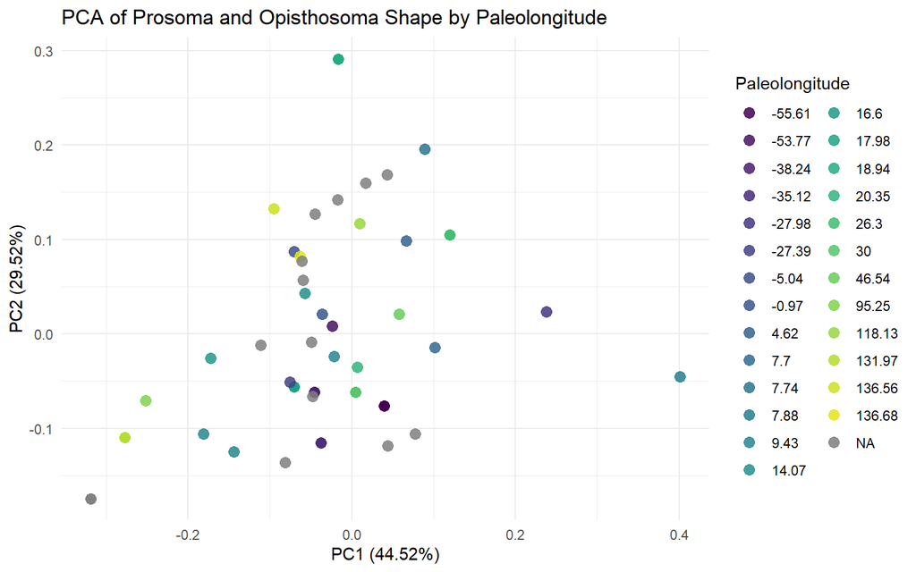

```r
library(ggplot2)
library(borealis)
#Full body points

#Attach coords to PCA
fb_coords <- hsc_coords[match(dimnames(fbb_pca$x)[[1]], hsc_coords[,1]),]
paleolong <- as.factor(fb_coords$paleolng_new)

#Make R treat coords like numbers
levels(paleolong) <- sort(as.numeric(levels(paleolong)))

#Attaching latitude
paleolat <- as.factor(fb_coords$paleolat_new)

#Same here, ordering it.
levels(paleolat) <- sort(as.numeric(levels(paleolat)))

#Original Plot
shape.space(fbb_pca, main.title = "PCA of Prosoma and Opisthosoma Shape by Paleolongitude", group.title = "Paleolongitude", group=paleolong, include.legend = TRUE, pt.size =3)
```

I hate this. There is no way to treat latitude/longitude as a continuous variable. I need to redo it or I will explode.

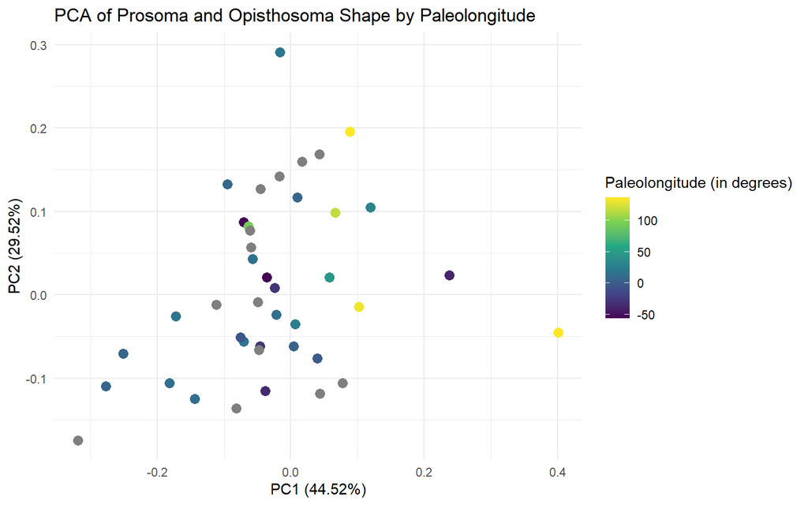

```r
fbb_pca_pts <- fbb_pca$x[,1:2]
fbb_pca_pts <- cbind(fbb_pca_pts, fb_coords)
fbb_pca_pts$paleolng_new <- as.numeric(fbb_pca_pts$paleolng_new)
fbb_pca_pts$paleolat_new <- as.numeric(fbb_pca_pts$paleolat_new)

ggplot(fbb_pca_pts, aes(x=Comp1, y=Comp2, color=paleolng_new))+
  geom_point(size=3)+
  scale_color_viridis_c("Paleolongitude (in degrees)")+
  labs(title= "PCA of Prosoma and Opisthosoma Shape by Paleolongitude", x = "PC1 (44.52%)", y="PC2 (29.52%)")+
  theme_minimal()
```

Now for latitude:

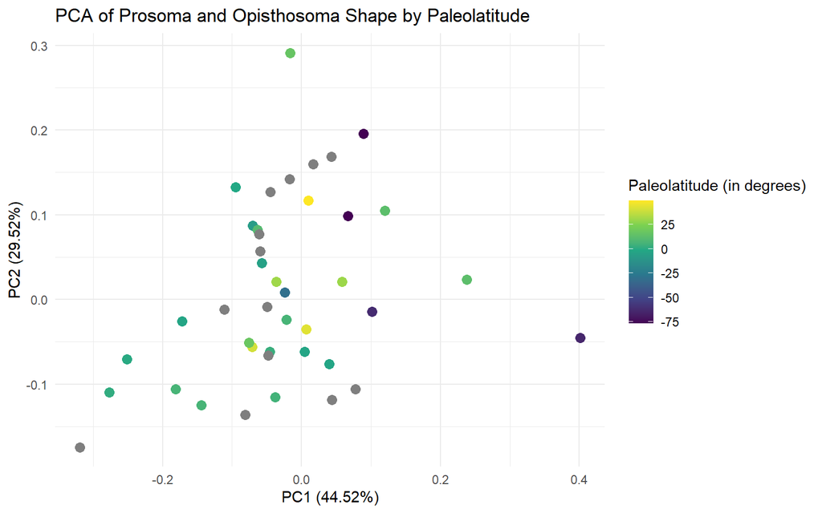

```r
ggplot(fbb_pca_pts, aes(x=Comp1, y=Comp2, color=paleolat_new))+
  geom_point(size=3)+
  scale_color_viridis_c("Paleolatitude (in degrees)")+
  labs(title= "PCA of Prosoma and Opisthosoma Shape by Paleolatitude", x = "PC1 (44.52%)", y="PC2 (29.52%)")+
  theme_minimal()
```

Again, most taxa are near the equator (paleolatitude of 0), however, the upper right and center portion of morphospace (Austrolimulids) has a cluster found at high latitudes.

## Conclusion

Xiphosurids seem to occur in tropical to subtropical latitudes throughout their geological history,with the exception of some Austrolimulids based on the latitude limits set by Hopkins (2014). Longitude has no visible correlation to morphospace, aside from high longitudes associated with some Austrolimulids.

## Why I did this project/Final Remarks

I was curious to see if there was any correlation between region of morphospace occupied and specifically, latitude preference. This was inspired by Hopkins, 2014.

This was a really fun class. I enjoyed the papers we read and gained a little bit more confidence in myself as a scientist, especially in regards to speaking up.

## Citations

Adams, D.C., Collyer, M. L., and Kaliontzopoulou, A., 2020, Geomorph: Software for geometric morphometric analyses. R package version 3.2.1. https://cran.r-project.org/package=geomorph.

Angelini, D., 2021, borealis: Tools for reproducible geometric morphometric analysis. R package version 2021.03.02. https://github.com/aphanotus/borealis

Hopkins, M.J., 2014, The environmental structure of trilobite morphological disparity: Paleobiology, v. 40, p. 352–373, doi: 10.1666/13049.

Hijmans, R.J., 2021, geosphere: Spherical Trigonometry. R package version 1.5-14. https://CRAN.R-project.org/package=geosphere

Kocsis, Á.T., Raja, N.B., 2020, chronosphere: Earth system history variables. R package version 0.4.1. https://doi.org/10.5281/zenodo.3530703.

Lamsdell, J.C., 2020, The phylogeny and systematics of Xiphosura.: PeerJ, v. 8, p. e10431, doi: 10.7717/peerj.10431.

Paleobiology Database, 2021, Paleobiology Database Occurrences of Xiphosura: https://paleobiodb.org/data1.2/occs/list.csv?base_name=Xiphosura&show=class,classext,coords,loc,paleoloc/(accessed November 2021)

Scotese, C.R., and Wright, N., 2018, PALEOMAP Paleodigital Elevation Models (PaleoDEMS) for the Phanerozoic: https://www.earthbyte.org/paleodem-resource-scotese-and-wright-2018/ (accessed December 2021)

van Hinsbergen, D.J.J., de Groot, L.V., van Schaik, S.J., Spakman, W., Bijl, P.K., Sluijs, A., Langereis, C.G., Brinkhuis, H., 2015, A Paleolatitude Calculator for Paleoclimate Studies: PLOS ONE, v. 10, no. 6, p. e0126946, doi: 10.1371/journal.pone.0126946

Wickham, H., 2016, ggplot2: Elegant Graphics for Data Analysis: Springer-Verlag, 266 p.